# The Most Dangerous Boston Neighborhoods

by Medha Kuruganti

## Motivation

When you look up the most dangerous neighborhoods in Boston, you'll often find the same couple of options: Roxbury, Mattapan, and Dorchester. And as someone from Massachsuetts, this is consistent with what people generally believe. Growing up, I was always told that these areas were extremely dangerous, and I should ultimately avoid them as much as possible. Now, part of me always believed that some of this had to do with the racial demographics of these neighborhoods. Overall, Massachusetts is predominantly white. However, as the state capital, Boston's demographics tend to vary more than the suburbs. According to the [Massachusetts Census](https://www.census.gov/quickfacts/bostoncitymassachusetts), 44.7% of Boston's population is White, while 24.2% is Black, 9.8% is Asian, and 19.5% is Hispanic/Latino. At the same time, as of 2019, the demographics in the 3 most dangerous neighborhoods in Boston are as follows:

- Roxbury: 50.3% Black, 30.7% Hispanic, 11% White, 3.5% Asian
- Mattapan: 74.4% Black, 14.1% Hispanic, 6% White, 1.9% Asian
- Dorchester: 44% Black, 19.9% Hispanic, 22.3% White, 9.9% Asian

In all 3 of these neighborhoods, we can see that there are more people of color, and specifically, more Black and Hispanic populations than White populations in these neighborhoods. But, now that I am much older, I do not want racial biases to influence my opinions on the danger levels of the neighborhoods in my favorite city. Thus, I will be analyzing the danger levels of the major Boston neighborhoods to determine which ones truly are the most dangerous.

After I explore the ways in which Boston neighborhoods are dangerous, I will look to see if there is a relationship between the dangerousness of a neighborhood and whether or not the majority of the population is POC or not. *I am not doing this analysis to encourage the belief that majority POC neighborhoods are possibly more dangerous.* I am doing this analysis to see if, first, there is even any type of relationship between race and danger (although, I do not believe there is), and second, to emphasize that possible high rates of crime in majority POC neighborhoods are a result of bad infrastructure and lack of societal aid.

## Development Requirements

To reproduce this project, it is important to not only have specific python libraries installed, but it is also important to use analytical abilities to come to conclusions. The following are required:

- Datasets:
  - [Crime Incident Reports in Boston 2022](https://data.boston.gov/dataset/6220d948-eae2-4e4b-8723-2dc8e67722a3/resource/313e56df-6d77-49d2-9c49-ee411f10cf58/download/tmphpcrbasd.csv)
  - [Boston Neighborhood Data 2020](https://data.boston.gov/dataset/7846ff3b-b738-47a3-a57e-19de2c753220/resource/5800a0a2-6acd-41a3-9fe0-1bf7b038750d/download/boston-neighborhood-data.csv)
- Reports/Articles:
  - [Massachusetts Census Data](https://www.census.gov/quickfacts/bostoncitymassachusetts)
  - [Boston Police Department Districts](https://bpdnews.com/districts)
  - [Guide to Boston's South End](https://www.rent.com/blog/south-end-boston-neighborhood-guide/#:~:text=Today%2C%20with%20its%20economic%20diversity,par%20with%20Boston%20in%20total)
  - [The Criminalization of Gentrifying Neighborhoods](https://www.theatlantic.com/politics/archive/2017/12/the-criminalization-of-gentrifying-neighborhoods/548837/)
  - [Black communities are disproportionately hurt by gun violence. We can’t ignore them.](https://projects.publicsource.org/pittsburgh-gun-violence-1/)
  - [GUN VIOLENCE IS A RACIAL JUSTICE ISSUE](https://www.bradyunited.org/issue/gun-violence-is-a-racial-justice-issue)
- Python Libraries
  - `requests`
  - `pandas`
  - `numpy`
  - `matplotlib.pyplot`
  - `re` for regex
  - `seaborn`

## Data Collection

```python
import requests
import pandas as pd
import numpy as np
```

I chose to analyze the crime data in Boston neighborhoods. Here, I got all the crime incident reports in 2022 in Boston (based on district/location). I dropped all rows with missing data (e.g., latitudes and longitudes that were set to (0,0), districts that were not in Boston, and NaN values. I also dropped columns that were not relevant to any analysis I performed. The only columns from this dataset that I used were: `OFFENSE_DESCRIPTION` and `DISTRICT`.

With this dataset, I created 2 different dataframes for my analyses and hypotheses testing. These dataframes were divided by the dataset's `OFFENSE_DESCRIPTION` and `SHOOTING` columns.

```python
# get all the crime incident reports in 2022 in Boston based on district/location
crime_table = pd.read_csv("https://data.boston.gov/dataset/6220d948-eae2-4e4b-8723-2dc8e67722a3/\
resource/313e56df-6d77-49d2-9c49-ee411f10cf58/download/tmphpcrbasd.csv")


# drop all the locations without coordinates, external districts, NaN values
crime_table = crime_table.loc[(crime_table["Lat"] != 0.0) & (crime_table["Long"] != 0.0)
                             & (crime_table["DISTRICT"] != "External")]
crime_table.dropna(axis=0, inplace=True, subset=["DISTRICT"])

# dataframe with only locations and shootings
df = crime_table.loc[:,["DISTRICT","SHOOTING"]]

# drop unnecessary columns
crime_table = crime_table.loc[:, ["OFFENSE_DESCRIPTION", "DISTRICT"]]
crime_table.head()
```

|  | OFFENSE_DESCRIPTION | DISTRICT |
| --- | --- | --- |
| 1 | INVESTIGATE PERSON | D14 |
| 3 | VERBAL DISPUTE | C11 |
| 4 | M/V - LEAVING SCENE - PROPERTY DAMAGE | B2 |
| 5 | AUTO THEFT | C6 |
| 6 | ROBBERY | D4 |

```python
# data for shootings and districts
df.head()
```

|  | DISTRICT | SHOOTING |
| --- | --- | --- |
| 1 | D14 | 0 |
| 3 | C11 | 0 |
| 4 | B2 | 0 |
| 5 | C6 | 0 |
| 6 | D4 | 0 |

I also looked at the racial demographics in each neighborhood. This data was used in the **Hypothesis Testing** section. Unfortunately, there was no data available for 2022 (which made sense) nor for 2021, so this data is from 2020. This could skew my data as the crime reports are from 2022 but the racial demographics are from 2020; however, I do not think the data will be that skewed given that a population does not change that much in 2 years.

In this dataset, I created a dataframe out of the relevant columns (i.e., the racial demographic breakdown) and renamed the columns for ease of reading.

```python
# data for racial demographics (as of 2020)
neighborhood_data = pd.read_csv("https://data.boston.gov/dataset/7846ff3b-b738-47a3-a57e-19de2c753220/resource/\
5800a0a2-6acd-41a3-9fe0-1bf7b038750d/download/boston-neighborhood-data.csv")

# only get the columns for the racial demographics for all ages
neighborhood_data = neighborhood_data.loc[:,["nbhd","P0020001","P0020005", "P0020006", "P0020002", "P002aapi",\
                                             "P002others"]]

# rename the columns to what they are
neighborhood_data = neighborhood_data.rename(columns={"nbhd": "NEIGHBORHOOD", "P0020001": "Total", "P0020005": "White",\
                                                      "P0020006": "Black/African American", "P0020002": "Hispanic/Latino",\
                                                      "P002aapi": "AAPI", "P002others": "Other"})

# delete the first row (has what the columns mean)
neighborhood_data = neighborhood_data.iloc[1:, :]

neighborhood_data.head()
```

|  | NEIGHBORHOOD | Total | White | Black/African American | Hispanic/Latino | AAPI | Other |
| --- | --- | --- | --- | --- | --- | --- | --- |
| 1 | Allston | 28621 | 14634 | 1451 | 3657 | 7173 | 1706 |
| 2 | Back Bay | 19588 | 14056 | 718 | 1326 | 2604 | 884 |
| 3 | Beacon Hill | 9336 | 7521 | 252 | 537 | 630 | 396 |
| 4 | Brighton | 48330 | 30596 | 2289 | 4978 | 7801 | 2666 |
| 5 | Charlestown | 19120 | 13626 | 990 | 2075 | 1650 | 779 |

## Data Processing

To make the analysis easier, I labeled each district with its correpsonding Boston neighborhood. This information was taken from https://bpdnews.com/districts. This will also later help when doing hypothesis testing with the racial make-up of each neighborhood.

In this dataset, it is important to note that not every neighborhood in Boston is accounted for. I only look at the neighborhoods that have distinct data about crimes - which I would assume are the neighborhoods with more crime as there are reports.

```python
# label each row with neighborhood that matches its district
neighborhood = []
for idx, row in crime_table.iterrows():
    if row["DISTRICT"] == "D14":
        neighborhood.append("Brighton")
    elif row["DISTRICT"] == "C11":
        neighborhood.append("Dorchester")
    elif row["DISTRICT"] == "B2":
        neighborhood.append("Roxbury")
    elif row["DISTRICT"] == "C6":
        neighborhood.append("South Boston")
    elif row["DISTRICT"] == "D4":
        neighborhood.append("South End")
    elif row["DISTRICT"] == "A1":
        neighborhood.append("Downtown")
    elif row["DISTRICT"] == "E13":
        neighborhood.append("Jamaica Plain")
    elif row["DISTRICT"] == "A15":
        neighborhood.append("Charlestown")
    elif row["DISTRICT"] == "E5":
        neighborhood.append("West Roxbury")
    elif row["DISTRICT"] == "E18":
        neighborhood.append("Hyde Park")
    elif row["DISTRICT"] == "B3":
        neighborhood.append("Mattapan")
    elif row["DISTRICT"] == "A7":
        neighborhood.append("East Boston")

crime_table["NEIGHBORHOOD"] = neighborhood
crime_table.head()
```

|  | OFFENSE_DESCRIPTION | DISTRICT | NEIGHBORHOOD |
| --- | --- | --- | --- |
| 1 | INVESTIGATE PERSON | D14 | Brighton |
| 3 | VERBAL DISPUTE | C11 | Dorchester |
| 4 | M/V - LEAVING SCENE - PROPERTY DAMAGE | B2 | Roxbury |
| 5 | AUTO THEFT | C6 | South Boston |
| 6 | ROBBERY | D4 | South End |

```python
# label each row with neighborhood that matches its district
neighborhood = []
for idx, row in df.iterrows():
    if row["DISTRICT"] == "D14":
        neighborhood.append("Brighton")
    elif row["DISTRICT"] == "C11":
        neighborhood.append("Dorchester")
    elif row["DISTRICT"] == "B2":
        neighborhood.append("Roxbury")
    elif row["DISTRICT"] == "C6":
        neighborhood.append("South Boston")
    elif row["DISTRICT"] == "D4":
        neighborhood.append("South End")
    elif row["DISTRICT"] == "A1":
        neighborhood.append("Downtown")
    elif row["DISTRICT"] == "E13":
        neighborhood.append("Jamaica Plain")
    elif row["DISTRICT"] == "A15":
        neighborhood.append("Charlestown")
    elif row["DISTRICT"] == "E5":
        neighborhood.append("West Roxbury")
    elif row["DISTRICT"] == "E18":
        neighborhood.append("Hyde Park")
    elif row["DISTRICT"] == "B3":
        neighborhood.append("Mattapan")
    elif row["DISTRICT"] == "A7":
        neighborhood.append("East Boston")

df["NEIGHBORHOOD"] = neighborhood
df.head()
```

|  | DISTRICT | SHOOTING | NEIGHBORHOOD |
| --- | --- | --- | --- |
| 1 | D14 | 0 | Brighton |
| 3 | C11 | 0 | Dorchester |
| 4 | B2 | 0 | Roxbury |
| 5 | C6 | 0 | South Boston |
| 6 | D4 | 0 | South End |

Now that I have the locations of each of these districts, I will be grouping the data by levels of danger. In this case, crimes like shootings, murders, and manslaughter would be the highest crimes, while vandalism and shoplifting would be the lowest crimes. These levels were determined by my personal opinions of these crimes and how horrible they are.

When looking at the danger levels, it is important to note that **Danger Level 1** is the least dangerous while **Danger Level 5** is the most dangerous. As mentioned before, these levels were determined by my own opinions and what society seemingly believes regarding danger levels. The levels are determined as follows:

- **Danger Level 1:** crimes related to high noise levels, vandalism/graffiti, public disputes (non-dangerous), low violations (license, evading fare, trespassing, etc)
- **Danger Level 2:** crimes related to motor vehicle accidents/property damage
- **Danger Level 3:** crimes related robbery, embezzlement, and fraud
- **Danger Level 4:** crimes related to bodily harm (i.e., threats, harrassment, abuse, kidnapping, assault)
- **Danger Level 5:** crimes related to illegal drug and alcohol violations and death (i.e., bombs/weapons, murder/manslaughter)
  - It could be argued that illegal drug and alcohol violations should not belong in this level, but based on the way police/society treats this, I kept it in this category. From a quick glance, it does not seem like these will overpower the category and make neighborhoods have high **Danger Level 5** scores; however, it is a possibility that I did not account for.

Additionally, I dropped rows that did not seem like crimes, or that did not give sufficient information for what crime occured. Many of these crimes were accidents in which the person themselves was injured or suffered, were not crimes, were deaths (but the death either was not a crime or the cause was not mentioned), there were no injuries/consequences, or the crime was resolved by the time it was recorded. These were labeled as NaN values and then dropped. These included:

- INVESTIGATE PERSON
- INVESTIGATE PROPERTY
- AIRCRAFT INCIDENTS
- ANIMAL INCIDENTS (DOG BITES, LOST DOG, ETC)
- TOWED MOTOR VEHICLE
- SICK ASSIST
- INJURY BICYCLE NO M/V INVOLVED
- M/V ACCIDENT - OTHER
- PROPERTY - FOUND
- M/V ACCIDENT - PERSONAL INJURY
- SICK/INJURED/MEDICAL - PERSON
- PROPERTY - STOLEN THEN RECOVERED
- WARRANT ARREST - OUTSIDE OF BOSTON WARRANT
- FIRE REPORT
- M/V ACCIDENT - INVOLVING PEDESTRIAN - NO INJURY
- RECOVERED - MV RECOVERED IN BOSTON (STOLEN OUTSIDE BOSTON)
- MISSING PERSON - LOCATED
- SICK ASSIST - DRUG RELATED ILLNESS
- SUDDEN DEATH
- MISSING PERSON - NOT REPORTED - LOCATED
- DEATH INVESTIGATION
- FIRE REPORT/ALARM - FALSE
- TRUANCY / RUNAWAY
- CONSPIRACY EXCEPT DRUG LAW
- SERVICE TO OTHER AGENCY
- M/V ACCIDENT - INVOLVING BICYCLE - NO INJURY
- RECOVERED - MV RECOVERED IN BOSTON (STOLEN IN BOSTON) MUST BE SUPPLEMENTAL
- SICK/INJURED/MEDICAL - POLICE
- M/V - LEAVING SCENE - PERSONAL INJURY
- PROPERTY - LOST THEN LOCATED
- HARBOR INCIDENT / VIOLATION
- INTIMIDATING WITNESS
- SUICIDE / SUICIDE ATTEMPT
- DANGEROUS OR HAZARDOUS CONDITION
- FUGITIVE FROM JUSTICE
- LARCENY PURSE SNATCH - NO FORCE
- CHILD REQUIRING ASSISTANCE (FOMERLY CHINS)
- PRISONER - SUICIDE / SUICIDE ATTEMPT
- FIREARM/WEAPON - LOST
- DRUNKENNESS

```python
import re

danger_lev = []

for idx, row in crime_table.iterrows():

    # danger level 1
    if (row["OFFENSE_DESCRIPTION"] == "AFFRAY" or row["OFFENSE_DESCRIPTION"] == "VERBAL DISPUTE" or
        row["OFFENSE_DESCRIPTION"] == "TRESPASSING" or row["OFFENSE_DESCRIPTION"] == "VANDALISM" or
        row["OFFENSE_DESCRIPTION"] == "VIOLATION - CITY ORDINANCE" or
        row["OFFENSE_DESCRIPTION"] == "PROPERTY - ACCIDENTAL DAMAGE" or
        row["OFFENSE_DESCRIPTION"] == "NOISY PARTY/RADIO-NO ARREST" or
        row["OFFENSE_DESCRIPTION"] == "DISTURBING THE PEACE/ DISORDERLY CONDUCT/ GATHERING CAUSING ANNOYANCE/ NOISY PAR" or
        row["OFFENSE_DESCRIPTION"] == "M/V PLATES - LOST" or row["OFFENSE_DESCRIPTION"] == "EVADING FARE" or
        row["OFFENSE_DESCRIPTION"] == "GRAFFITI" or row["OFFENSE_DESCRIPTION"] == "VAL - OPERATING AFTER REV/SUSP." or
        row["OFFENSE_DESCRIPTION"] == "VAL - VIOLATION OF AUTO LAW" or row["OFFENSE_DESCRIPTION"] == "AFFRAY" or
        row["OFFENSE_DESCRIPTION"] == "LICENSE PREMISE VIOLATION" or
        row["OFFENSE_DESCRIPTION"] == "VAL - OPERATING W/O AUTHORIZATION LAWFUL"):
        danger_lev.append(1)

    # danger level 2
    elif (row["OFFENSE_DESCRIPTION"] == "M/V - LEAVING SCENE - PROPERTY DAMAGE" or
          row["OFFENSE_DESCRIPTION"] == "M/V ACCIDENT - OTHER CITY VEHICLE" or
          row["OFFENSE_DESCRIPTION"] == "M/V ACCIDENT - PROPERTY DAMAGE" or
          row["OFFENSE_DESCRIPTION"] == "M/V ACCIDENT - POLICE VEHICLE"):
        danger_lev.append(2)

    # danger level 3
    elif re.match(r"LARCENY ", row["OFFENSE_DESCRIPTION"]):
        danger_lev.append(3)

    elif re.match(r"AUTO THEFT", row["OFFENSE_DESCRIPTION"]):
        danger_lev.append(3)

    elif re.match(r"FRAUD - ", row["OFFENSE_DESCRIPTION"]):
        danger_lev.append(3)

    # danger level 4
    elif (row["OFFENSE_DESCRIPTION"] == "ROBBERY" or
          row["OFFENSE_DESCRIPTION"] == "BREAKING AND ENTERING (B&E) MOTOR VEHICLE (NO PROPERTY STOLEN)" or
          row["OFFENSE_DESCRIPTION"] == "BURGLARY - COMMERICAL" or
          row["OFFENSE_DESCRIPTION"] == "FORGERY / COUNTERFEITING" or
          row["OFFENSE_DESCRIPTION"] == "EXTORTION OR BLACKMAIL" or
          row["OFFENSE_DESCRIPTION"] == "EMBEZZLEMENT" or
          row["OFFENSE_DESCRIPTION"] == "POSSESSION OF BURGLARIOUS TOOLS"):
        danger_lev.append(3)

    elif re.match(r"ASSAULT - ", row["OFFENSE_DESCRIPTION"]):
        danger_lev.append(4)

    elif (row["OFFENSE_DESCRIPTION"] == "THREATS TO DO BODILY HARM" or
         row["OFFENSE_DESCRIPTION"] == "M/V ACCIDENT - INVOLVING PEDESTRIAN - INJURY" or
         row["OFFENSE_DESCRIPTION"] == "HARASSMENT/ CRIMINAL HARASSMENT" or
         row["OFFENSE_DESCRIPTION"] == "ANIMAL ABUSE" or
         row["OFFENSE_DESCRIPTION"] == "KIDNAPPING/CUSTODIAL KIDNAPPING/ ABDUCTION" or
         row["OFFENSE_DESCRIPTION"] == "MISSING PERSON"):
        danger_lev.append(4)

    # danger level 5
    elif (row["OFFENSE_DESCRIPTION"] == "DRUGS - POSSESSION/ SALE/ MANUFACTURING/ USE" or
         row["OFFENSE_DESCRIPTION"] == "BALLISTICS EVIDENCE/FOUND" or
         row["OFFENSE_DESCRIPTION"] == "FIREARM/WEAPON - FOUND OR CONFISCATED" or
         row["OFFENSE_DESCRIPTION"] == "OPERATING UNDER THE INFLUENCE (OUI) ALCOHOL" or
         row["OFFENSE_DESCRIPTION"] == "BOMB THREAT" or
         row["OFFENSE_DESCRIPTION"] == "MURDER, NON-NEGLIGENT MANSLAUGHTER" or
         row["OFFENSE_DESCRIPTION"] == "EXPLOSIVES - TURNED IN OR FOUND" or
         row["OFFENSE_DESCRIPTION"] == "LIQUOR LAW VIOLATION"):
        danger_lev.append(5)

    # any other crime will be labeled as NaN
    else:
        danger_lev.append(np.nan)

crime_table["DANGER LEVEL"] = danger_lev
```

```python
# drop the NaN values (i.e., the crimes I am not considering to be crimes
# because of a lack of information or the belief it is not a crime like the others

crime_table.dropna(axis=0, inplace=True, subset=["DANGER LEVEL"])
crime_table.head()
```

|  | OFFENSE_DESCRIPTION | DISTRICT | NEIGHBORHOOD | DANGER LEVEL |
| --- | --- | --- | --- | --- |
| 3 | VERBAL DISPUTE | C11 | Dorchester | 1.0 |
| 4 | M/V - LEAVING SCENE - PROPERTY DAMAGE | B2 | Roxbury | 2.0 |
| 5 | AUTO THEFT | C6 | South Boston | 3.0 |
| 6 | ROBBERY | D4 | South End | 3.0 |
| 7 | LARCENY ALL OTHERS | D14 | Brighton | 3.0 |

Now that I properly processed the data for analysis on danger levels, I will be processing the data about racial demographics. In the **Hypothesis Testing** section, I look at the relationship between different danger ratings and the percent of POC (person of color/non-white) populations in each neighborhood to see if there is a relationship. Because of this, I process the dataframe to only include the neighborhoods with crime reports, and then count the number of POC populations (i.e., non-white, so this includes the categories of `Black/African American`, `Hispanic/Latino`, `AAPI`, and `Other`). I also find the percentage for each of these categories so it is easier to compare the neighborhoods.

```python
# make neighborhood table have only the neighborhoods we are looking at

nhoods = crime_table["NEIGHBORHOOD"].unique()

for idx, row in neighborhood_data.iterrows():
    if not(row["NEIGHBORHOOD"] in nhoods):
        neighborhood_data.drop(index=idx, inplace=True)
```

```python
# get the total number of POC individuals in each neighborhood and add it as a column
poc = []
dem = ["Black/African American", "Hispanic/Latino", "AAPI", "Other"]

for idx, row in neighborhood_data.iterrows():
    total = 0

    for d in dem:
        total += int(row[d])

    poc.append(total)

neighborhood_data["POC"] = poc
```

```python
# convert all of the population counts to percentages for ease of analysis
dem = ["White", "Black/African American", "Hispanic/Latino", "AAPI", "Other", "POC"]

for idx, row in neighborhood_data.iterrows():
    for d in dem:
        neighborhood_data.loc[idx, d] = (float(row[d])/float(row["Total"])) * 100

neighborhood_data.head()
```

|  | NEIGHBORHOOD | Total | White | Black/African American | Hispanic/Latino | AAPI | Other | POC |
| --- | --- | --- | --- | --- | --- | --- | --- | --- |
| 4 | Brighton | 48330 | 63.306435 | 4.736189 | 10.300021 | 16.141113 | 5.516242 | 36.693565 |
| 5 | Charlestown | 19120 | 71.26569 | 5.177824 | 10.85251 | 8.629707 | 4.074268 | 28.734310 |
| 7 | Dorchester | 122191 | 22.432912 | 34.956748 | 20.693013 | 10.933702 | 10.983624 | 77.567088 |
| 8 | Downtown | 13451 | 68.203108 | 3.992268 | 7.14445 | 16.995019 | 3.665155 | 31.796892 |
| 9 | East Boston | 43066 | 36.594994 | 3.25779 | 50.387777 | 4.486138 | 5.273301 | 63.405006 |

## Exploratory Analysis

In this part of the project, I will be analyzing how dangerous each of the Boston neighborhoods are. This will be done in 3 different ways:

1. Determine which neighborhoods are the most dangerous by their relative recorded crime reports to each other.
2. Determine which neighborhoods are the most dangerous by the danger levels.
3. Determine which neighborhoods are the most dangerous based on the number of shootings (which would be similar to having a danger level of 5 or higher).

### Part 1: Danger by relative recorded crime reports

In this section, I will get the total crime reports (regardless of danger level) for each of the neighborhoods. Since reports of shootings and offense descriptions can both exist for a crime, I do not count them separately. Once I get the total counts for each neighborhood, I create a pie chart to compare the relative amount of crime that occurs in each neighborhood.

```python
import matplotlib.pyplot as plt
```

```python
# get the total crime reports for each neighborhood
nhoods = crime_table["NEIGHBORHOOD"].unique()
nhoods.sort()

total_crime = [0]*12
idx = 0

for n in nhoods:
    crime = len(crime_table[crime_table["NEIGHBORHOOD"] == n])
    total_crime[idx] = crime
    idx += 1

data = {"NEIGHBORHOOD": nhoods, "Total Crime": total_crime}
total_crime_by_nhood = pd.DataFrame(data)
```

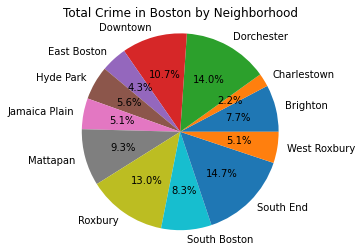

```python
plt.title("Total Crime in Boston by Neighborhood")
plt.pie(total_crime, labels=nhoods, autopct='%1.1f%%')
plt.axis("equal")
plt.show()
```

According to this plot, the neighborhoods with the top crime reports are the South End (14.7%), Dorchester (14.0%), and Roxbury (13.0%). This is in comparison to the total crime in Boston. This also only considers the crime reports that I considered crimes previously. As a result, these numbers are biased as to what I considered sufficient enough information for a crime or that I determined to be a crime.

While I am unsure whether or not the data would be different had I included all of the crimes, we can see that there is a discrepancy here between what the Internet claims are the most dangerous neighborhoods and what my analysis shows. If I consider danger by the number of crimes that occur, then the South End and Dorchester should be the most dangerous cities with Roxbury right behind them. But while we see Dorchester and Roxbury being dangerous neighborhoods, the South End is not necessarily known for its high crime levels.

Because of this discrepancy, I now look at the relative dangers of each of these neighborhood to see if I get different results. Reports (such as [this one](https://www.rent.com/blog/south-end-boston-neighborhood-guide/#:~:text=Today%2C%20with%20its%20economic%20diversity,par%20with%20Boston%20in%20total)) have shown that the South End does have dangerous areas, but has relatively low violent crime. As a result, I will also look at the relative number of crimes and their danger levels to see if neighborhoods with more crime have less dangerous crimes.

### Part 2: Danger based on danger levels

In this section, I analyze how dangerous each neighborhood is based on which level of crime is the most prevalent in the neighborhood. This is done by grouping the data by neighborhood and danger level, looking at their relative crimes through a bar graph and looking at their relative crimes through a pie chart for each neighborhood.

First, I look at the mean danger levels for each neighborhood. This gives us a very basic idea of how dangerous each neighborhood is. From these values, we can see which neighborhoods may have the highest danger levels.

```python
# get the mean danger level for each neighborhood
crime_table.groupby(by=["NEIGHBORHOOD"]).mean()
```

| NEIGHBORHOOD | DANGER LEVEL |
| --- | --- |
| Brighton | 2.628950 |
| Charlestown | 2.620939 |
| Dorchester | 2.621348 |
| Downtown | 2.871701 |
| East Boston | 2.663603 |
| Hyde Park | 2.674682 |
| Jamaica Plain | 2.803101 |
| Mattapan | 2.735245 |
| Roxbury | 2.572296 |
| South Boston | 2.859182 |
| South End | 2.717112 |
| West Roxbury | 2.723502 |

From this data, it seems as though Downtown, South Boston, and Jamaica Plain are the most dangerous neighborhoods based on the average danger levels. Again, this information does not match neither the reported most dangerous neighhborhoods nor the most dangerous neighborhoods that I analyzed above by relative crime to each other.

Next, I group the crime by Neighborhood and danger level to analyze the relativity of danger among the crimes among all of the neighborhoods. This will allow me to see which neighborhoods have the most crime and the level of danger of the crimes they have.

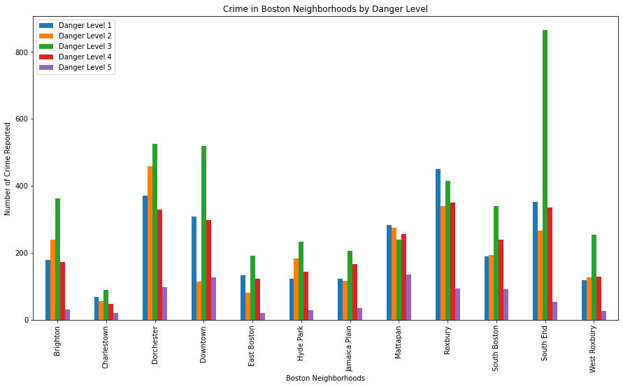

```python
# sort the levels for ease
levels = crime_table["DANGER LEVEL"].unique()
levels.sort()
levels

data = []

# for each danger level, go through the dataframe and count the number of crimes at that
# danger level for each neighborhood
# neighborhoods are sorted alphabetically for consistency among dataframes
for l in levels:
    danger = [0]*12

    for idx, row in crime_table[crime_table["DANGER LEVEL"] == l].iterrows():
        if row["NEIGHBORHOOD"] == "Brighton":
            danger[0] += 1
        elif row["NEIGHBORHOOD"] == "Charlestown":
            danger[1] += 1
        elif row["NEIGHBORHOOD"] == "Dorchester":
            danger[2] += 1
        elif row["NEIGHBORHOOD"] == "Downtown":
            danger[3] += 1
        elif row["NEIGHBORHOOD"] == "East Boston":
            danger[4] += 1
        elif row["NEIGHBORHOOD"] == "Hyde Park":
            danger[5] += 1
        elif row["NEIGHBORHOOD"] == "Jamaica Plain":
            danger[6] += 1
        elif row["NEIGHBORHOOD"] == "Mattapan":
            danger[7] += 1
        elif row["NEIGHBORHOOD"] == "Roxbury":
            danger[8] += 1
        elif row["NEIGHBORHOOD"] == "South Boston":
            danger[9] += 1
        elif row["NEIGHBORHOOD"] == "South End":
            danger[10] += 1
        elif row["NEIGHBORHOOD"] == "West Roxbury":
            danger[11] += 1

    data.append(danger)

# create a dataframe from the data and plot it as a bar graph to check the relativity of crime
# among the neighborhoods
plotdata = pd.DataFrame({
    "Danger Level 1": data[0],
    "Danger Level 2": data[1],
    "Danger Level 3": data[2],
    "Danger Level 4": data[3],
    "Danger Level 5": data[4]},

    index=["Brighton", "Charlestown", "Dorchester", "Downtown", "East Boston",
           "Hyde Park", "Jamaica Plain", "Mattapan", "Roxbury", "South Boston",
           "South End", "West Roxbury"])

plotdata.plot(kind="bar", figsize=(15,8))
plt.title("Crime in Boston Neighborhoods by Danger Level")
plt.xlabel("Boston Neighborhoods")
plt.ylabel("Number of Crime Reported")
```

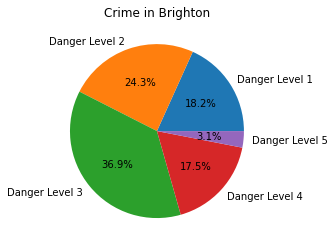

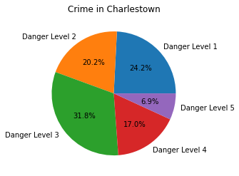

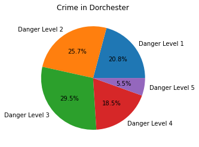

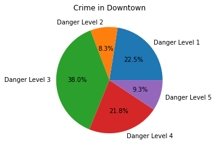

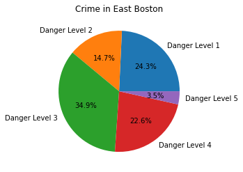

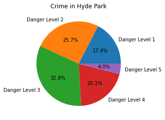

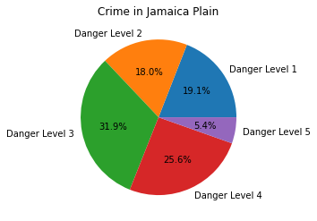

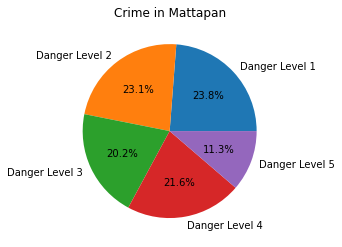

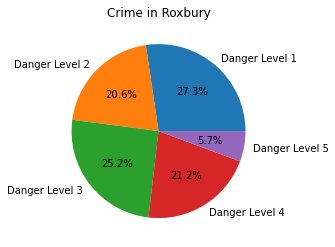

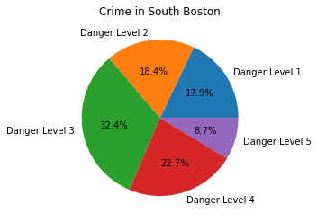

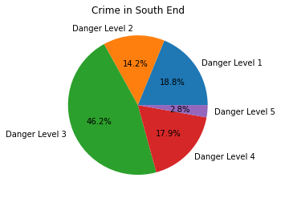

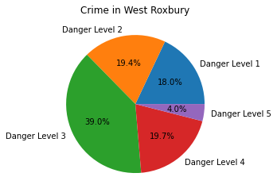

```python
# sort the neighborhoods for consistency among dataframes
nhoods = crime_table["NEIGHBORHOOD"].unique()
nhoods.sort()
nhoods

# for each neighborhood, count how many crimes of each danger level are present and then plot
# shows relativity of each type of crime in each neighborhood (shows out of total crime for each
# neighborhood)
for n in nhoods:
    data_lev = [0]*5

    for idx, row in crime_table[crime_table["NEIGHBORHOOD"] == n].iterrows():
        if row["DANGER LEVEL"] == 1:
            data_lev[0] += 1
        elif row["DANGER LEVEL"] == 2:
            data_lev[1] += 1
        elif row["DANGER LEVEL"] == 3:
            data_lev[2] += 1
        elif row["DANGER LEVEL"] == 4:
            data_lev[3] += 1
        elif row["DANGER LEVEL"] == 5:
            data_lev[4] += 1

    labels = ["Danger Level 1", "Danger Level 2", "Danger Level 3", "Danger Level 4", "Danger Level 5"]

    plt.title("Crime in " + n)
    plt.pie(data_lev, labels=labels, autopct='%1.1f%%')
    plt.show()
```

Interestingly enough, only two neighborhoods fall into the top 3 neighborhoods for each level of danger: Mattapan and Downtown. And more interestingly, both of these neighborhoods fall in the top 3 neighborhoods with the highest percentage of danger level 5 crimes.

Based on this data, we can see that Mattapan, Downtown, South Boston, and Jamaica Plain seem to be the most dangerous neighborhoods, based on their relative danger levels of crime. This is because they have the highest percentage of danger level 5 and danger level 4 crimes, where levels 5 and 4 refer to crimes that result in (the threat of) bodily harm and the posession of illegal/dangerous objects (i.e., drugs, weapons). These findings are consistent with the mean danger levels of the neighborhoods that I initially explored.

### Part 3: Danger by crime rate in relation to number of shootings

Now, I will analyze the relationship between the number of shootings and how dangerous a neighborhood is. In this analysis, I use data from the entire original dataframe (i.e., crimes that I may have determined as not crimes are still considered in this dataset).

```python
# sort the neighbrohoods for consistency
nhoods = df["NEIGHBORHOOD"].unique()
nhoods.sort()
nhoods

shooting_table = pd.DataFrame({"NEIGHBORHOOD": nhoods})

num_shootings = [0]*12
counter = 0

# count the number of shootings per neighborhood (shootings are defined as "1")
for n in nhoods:
    num_shoot = 0

    for idx, row in df[df["NEIGHBORHOOD"] == n].iterrows():
        if row["SHOOTING"] != 0:
            num_shoot += 1

    num_shootings[counter] = num_shoot
    counter += 1

shooting_table["SHOOTINGS"] = num_shootings

# sort the dataframe by max number of shootings to see which neighborhoods have most
shooting_table.sort_values(by=["SHOOTINGS"], ascending=False)
```

|  | NEIGHBORHOOD | SHOOTINGS |
| --- | --- | --- |
| 7 | Mattapan | 60 |
| 8 | Roxbury | 58 |
| 2 | Dorchester | 44 |
| 5 | Hyde Park | 19 |
| 10 | South End | 13 |
| 6 | Jamaica Plain | 9 |
| 9 | South Boston | 9 |
| 4 | East Boston | 7 |
| 11 | West Roxbury | 7 |
| 0 | Brighton | 6 |
| 3 | Downtown | 3 |
| 1 | Charlestown | 2 |

By analyzing the shooting, we see that the neighborhoods with the most recorded shootings: Mattapan, Roxbury, and Dorchester are also the ones that are most often seen to be the most violent/dangerous.

## Hypothesis Testing

Now that I have determined which neighborhoods are the most dangerous based on each analysis method, let's see if there is a relationship between racial demographics and high crime for each of the methods.

While I do not believe high danger and crime is a result of mainly POC neighborhoods, nor do I think that the reason why mainly POC neighborhoods may have high crime rates is because the neighborhoods' make-ups are predominantly POC (this ultimately is a result of a lack of societal aid), I do think it is important to see if there even is a relationship. If there is a relationship (i.e., there is higher crime in POC neighborhoods), then that means our society needs to invest more in these neighborhoods and provide aid to them in ways they need it. If not, then there's no reason for these biases to exist - although it is important to note that we should all be dispelling these biases regardless of the answer.

In the following graphs, we label majority POC neighborhoods in red, and majority White neighborhoods in black. The majority POC neighborhoods are: Dorchester, Roxbury, Mattapan, East Boston, and Hyde Park. The majority White neighborhoods are: the South End, Downtown, South Boston, Brighton, Jamaica Plain, West Roxbury, and Charlestown.

### Racial Demographics vs. Total Crime per Neighborhood

```python
import seaborn as sns; sns.set_theme(color_codes=True)

# merge the total crime by neighborhood dataframe and the neighborhood data dataframe
# gives one dataframe with total crime and demographics of neighborhood for graphing purposes
result1 = pd.merge(total_crime_by_nhood, neighborhood_data, on="NEIGHBORHOOD")
```

```python
# plot linear regression model to see if there is a reltionship between crime and racial demographics
def linreg_plot(df, x, y, title):
    fig, ax = plt.subplots()
    fig = sns.regplot(df[x], df[y])
    plt.title(title)

    # label majority POC neighborhoods red, and majority White black
    for idx, row in df.iterrows():
        if float(row["POC"]) > float(row["White"]):
            c = "red"
        else:
            c = "black"

        ax.annotate(row["NEIGHBORHOOD"], (df[x][idx],df[y][idx]), color=c)
```

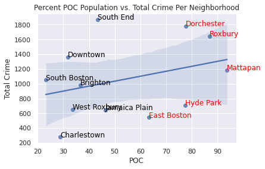

```python
# plot linear regression for total crime and neighborhood demographics (% POC)
linreg_plot(result1, "POC", "Total Crime", "Percent POC Population vs. Total Crime Per Neighborhood")
```

Looking at the above graph, we can see that there is no relationship between the total number of crimes and whether or not a neighborhood is majority POC or not. Clearly, the neighborhood with the most crime is the South End, which we can see to be majority White. Moreover, when we look at the graph, and our linear regression line, we see that half of the neighborhoods fall above the line and the other half below. In fact the majority (4/7) of neighborhoods that are majority White fall above the line while the majority of neighborhoods that are majority POC fall under the line (3/5). Based on this data, the belief that more crime occurs in majority POC neighborhoods is incorrect.

### Racial Demographics and Danger Levels

To analyze the realtionship between the racial demographics of each neighborhood and their danger through danger levels, I look at the relationship between the number of crimes at each level and the racial demographics of the neighborhood.

```python
danger_level1 = [0]*12
danger_level2 = [0]*12
danger_level3 = [0]*12
danger_level4 = [0]*12
danger_level5 = [0]*12

i = 0

# for each neighborhood get the number of crimes at each danger level
# organize by danger level
# neighborhoods are sorted alphabetically for consistency among dataframes

for n in nhoods:
    for idx, row in crime_table[crime_table["NEIGHBORHOOD"] == n].iterrows():
        if row["DANGER LEVEL"] == 1:
            danger_level1[i] += 1
        elif row["DANGER LEVEL"] == 2:
            danger_level2[i] += 1
        elif row["DANGER LEVEL"] == 3:
            danger_level3[i] += 1
        elif row["DANGER LEVEL"] == 4:
            danger_level4[i] += 1
        elif row["DANGER LEVEL"] == 5:
            danger_level5[i] += 1

    i += 1

danglevel1 = pd.DataFrame({"NEIGHBORHOOD": nhoods, "COUNT": danger_level1})
danglevel2 = pd.DataFrame({"NEIGHBORHOOD": nhoods, "COUNT": danger_level2})
danglevel3 = pd.DataFrame({"NEIGHBORHOOD": nhoods, "COUNT": danger_level3})
danglevel4 = pd.DataFrame({"NEIGHBORHOOD": nhoods, "COUNT": danger_level4})
danglevel5 = pd.DataFrame({"NEIGHBORHOOD": nhoods, "COUNT": danger_level5})
```

```python
# merge dataframes by level with racial demographics for ease of graphing

result_danglev1 = pd.merge(danglevel1, neighborhood_data, on="NEIGHBORHOOD")
result_danglev2 = pd.merge(danglevel2, neighborhood_data, on="NEIGHBORHOOD")
result_danglev3 = pd.merge(danglevel3, neighborhood_data, on="NEIGHBORHOOD")
result_danglev4 = pd.merge(danglevel4, neighborhood_data, on="NEIGHBORHOOD")
result_danglev5 = pd.merge(danglevel5, neighborhood_data, on="NEIGHBORHOOD")
```

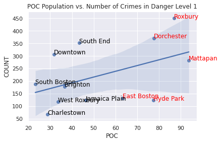

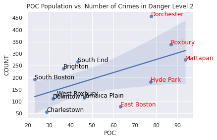

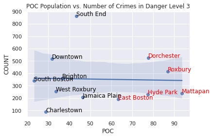

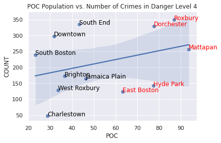

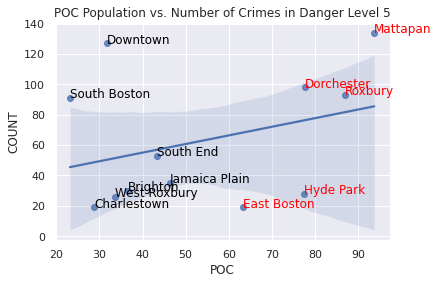

```python
# graph the (linear?) relationship between danger level and % POC population for each level and neighborhood

linreg_plot(result_danglev1, "POC", "COUNT", "POC Population vs. Number of Crimes in Danger Level 1")
linreg_plot(result_danglev2, "POC", "COUNT", "POC Population vs. Number of Crimes in Danger Level 2")
linreg_plot(result_danglev3, "POC", "COUNT", "POC Population vs. Number of Crimes in Danger Level 3")
linreg_plot(result_danglev4, "POC", "COUNT", "POC Population vs. Number of Crimes in Danger Level 4")
linreg_plot(result_danglev5, "POC", "COUNT", "POC Population vs. Number of Crimes in Danger Level 5")
```

#### Danger Level 1

While there is not an obvious relatioship between the number of **Danger Level 1** crimes and a neighborhood having a majority POC make-up, there is a slight relationship. The South End and Downtown seem to be outliers in this linear regression model, but Roxbury, Dorchester, and Mattapan do follow the linear regression model, showing more **Danger Level 1** crimes than the other majority White neighborhoods.

In this analysis, it is important to consider what **Danger Level 1** entails. These are crimes that are not very dangerous at all: loud noises, slight altercations, etc. There are studies/articles (e.g, [this one](https://www.theatlantic.com/politics/archive/2017/12/the-criminalization-of-gentrifying-neighborhoods/548837/)) that have shown that more POC areas have more noise, and White neighbors are more likely to call the police on them. So, in this case, although there may be a relationship between race and more **Danger Level 1** crimes, this could be a result of societal biases.

#### Danger Level 2

For **Danger Level 2**, we see a similar, but maybe more defined, relationship between majority POC neighborhoods and the amount of **Danger Level 2** crimes. Once again, these crimes are focused on motorvehicle accidents, so these are not necessarily crimes in the same way as other more dangerous crimes. While I have not done an analysis on it, this may just be a result of traffic or bad roads.

#### Danger Level 3

The **Danger Level 3** graph shows no siginificant relationship between the racial make-up of a neighborhood and the amount of **Danger Level 3** crimes. These are crimes related to fraud, larceny, embezzlement, and burglary. This refutes the belief that majority POC neighborhoods are mroe likely to be thiefs, and is a good example of why stores need not lock up products meant for Black populations (not that there was ever a reason, but this shows that there is *no* reason).

#### Danger Level 4

The **Danger Level 4** graph also shows no significant relationship between the racial make-up of a neighborhood and the amount of **Danger Level 4** crimes. While Roxbury and Dorchester have high amounts of **Danger Level 4** crimes, so do Downtown and the South End. These crimes are a bit more agressive, dealing with threats to bodily harm, kidnapping, assault, etc. But according to this regression analysis, these crimes exist almost equally in all of the neighborhoods.

### Racial Demographics and Number of Shootings

```python
# merge the number of shootings and neighborhoods into a dataframe for ease of graphing
result3 = pd.merge(shooting_table, neighborhood_data, on="NEIGHBORHOOD")
```

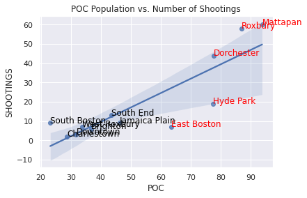

```python
# graph the (linear) relationship between danger level and % POC population for each level and neighborhood
linreg_plot(result3, "POC", "SHOOTINGS", "POC Population vs. Number of Shootings")
```

Based on the above graph, it is clear there is a relationship between the number of shootings and whether or not a neighborhood is majority POC or majority White. However, what we must take away from this analysis is that the consequences of segregation and disinvestment in these neighborhoods leads to higher violence (as seen by [this article](https://projects.publicsource.org/pittsburgh-gun-violence-1/) and [this article](https://www.bradyunited.org/issue/gun-violence-is-a-racial-justice-issue)). From this analysis, we must learn that, as a society, we are failing these neighborhoods that have more shootings and more prone to gun violence, rather than forcing them to fend for themselves.

## Insights

From this analysis, I would agree that Roxbury, Mattapan, and Dorchester are dangerous neighborhoods in Boston, but based on my analysis, so are the South End and Downtown. Based on the relativity of crime seen in the **Exploratory Analysis** section (through the total crime percentages and number of shootings) and the **Hypothesis Testing** section, it was clear that the three neighborhoods are often found for having quite a lot of crime. It is important to also note that Downtown and the South End often also showed up as high crime neighborhoods. While, as someone from Massachsuetts, I am not entirely surprised about the South End, I am slightly (but not completely) surprised that Downtown often made the top of the list. Simulateneously, while I argue that the South End and Downtown are just as dnagerous, Roxbury, Mattapan, and Dorchester have the most amount of shootings by a significant amount, so I will also argue that because of their high shooting rates, they are more dangerous than Downtown and the South End.

Beyond looking at the amount of crime in each neighborhood, it is also important to consider what leads to these crimes. In general, Boston has had a terrible relationship with individuals of color - and, especially, Black populations. Crime does lead to danger, but if the city of Boston and the Commonwealth of Massachusetts cannot see that high crime rates show a failure of society and the government to help these populations, then these neighborhoods will continue to have crime rates and will never be "safe". Additionally, it is important to consider how the gentrification of some of these neighborhoods leads to more crime reports because populations that think they are better move into these areas and call the police more often on their neighbors (for things that may not be actual crimes). Often, gentrification leads to more racial profiling, which could be cause for more crime reports - and supposedly more crimes. Finally, it's also important to consider if police are more often stationed in the areas that have been shown to have higher crime rates. If there is more policing in a neighborhood - and there often is more policing in majority POC areas - then of course the neighborhood will have more crime reports, even if they do not necessarily have more crime.